# La cultura política y el apoyo a la democracia en Chile durante 2021

# 10. Reporte de resultados

## 10.1 carga de librerías

## 10.2 carga de datos y visualización

# 11. Presentación de variables

Data frame: datos_proc

| ID | Name | Label | Values | Value Labels |
| --- | --- | --- | --- | --- |
| 1 | idencuesta | Folio identificador de participante | *range: 1101011-131230214* |  |
| 2 | estrato | Estrato muestral | *range: 1-6* |  |
| 3 | segmento | Ponderador Corte transvesal: Ajuste por población y sexo | *range: 110101-1420411* |  |
| 4 | ponderador02 |  | *range: 0.0-27.1* |  |
| 5 | confianza_gob | Grado de confianza: El Gobierno |  | Nada o poca Algo Bastante o mucha |
| 6 | confianza_pp | Grado de confianza: Los Partidos Politicos |  | Nada o poca Algo Bastante o mucha |
| 7 | confianza_congreso | Grado de confianza: El Congreso Nacional |  | Nada o poca Algo Bastante o mucha |
| 8 | confianza_pdte | Grado de confianza: El Presidente de la República |  | Nada o poca Algo Bastante o mucha |
| 9 | opina_rrss | Frecuencia: Usa redes sociales para opinar en temas publicos |  | Nunca o casi nunca A veces Frecuente o muy frecuentemente |
| 10 | interes_politica | ¿Qué tan interesado está usted en la política? |  | Nada o poco interesado Algo interesado Bastante o muy interesado |
| 11 | informa_politica | Frecuencia: Se informa sobre politica en medios de comunicacion |  | Nunca o casi nunca A veces Frecuente o muy frecuentemente |
| 12 | habla_politica | Frecuencia: Habla de politica con familiares o amigos |  | Nunca o casi nunca A veces Frecuente o muy frecuentemente |
| 13 | ident_ideologica | Autoubicacion escala izquierda-derecha |  | Izquierda Centro Derecha Independiente Ninguno |
| 14 | edad |  | *range: 21-85* |  |
| 15 | sexo | Sexo del entrevistada/o |  | Hombre Mujer |
| 16 | nivel_educ | Nivel educacional |  | Primaria Secundaria Educación técnica Universitaria o posgrado |
| 17 | fact_exp02 |  | *range: 3.2-146895.2* |  |
| 18 | satis_dem | ¿Cuán satisfecho o insatisfecho está usted con el funcionamiento de la democracia en Chile? |  | Nada o poco satisfecho Algo satisfecho Bastante o muy satisfecho |
| 19 | c25 | ¿Con cuál de las siguientes frases está usted más de acuerdo? | *range: 1-3* |  |
| 20 | apoyo_dem | ¿Con cuál de las siguientes frases está usted más de acuerdo? |  | La democracia es preferible a cualquier otra forma de gobierno En algunas circunstancias, un gobierno autoritario puede ser preferible a uno democratico A la gente como uno, nos da lo mismo un regimen… |
| 21 | edad_tramo | Edad por tramo |  | Joven Adulto Adulto mayor |
| 22 | apoyo_dem_dic | Democracia o autoritarismo | *range: 0-1* |  |

```
## 'data.frame':    1573 obs. of  22 variables:
##  $ idencuesta        : num  1101011 1101012 1101013 1101021 1101032 ...
##   ..- attr(*, "label")= chr "Folio identificador de participante"
##  $ estrato           : num  4 4 4 4 4 4 4 4 4 4 ...
##   ..- attr(*, "label")= chr "Estrato muestral"
##  $ segmento          : num  110101 110101 110101 110102 110103 ...
##   ..- attr(*, "label")= chr "Ponderador Corte transvesal: Ajuste por población y sexo"
##  $ ponderador02      : num  0,969 0,485 0,727 1,253 0,889 ...
##  $ confianza_gob     : Factor w/ 3 levels "Nada o poca",..: 1 1 1 1 1 1 1 1 2 1 ...
##   ..- attr(*, "label")= chr "Grado de confianza: El Gobierno "
##  $ confianza_pp      : Factor w/ 3 levels "Nada o poca",..: 1 1 1 1 1 1 1 1 1 1 ...
##   ..- attr(*, "label")= chr "Grado de confianza: Los Partidos Politicos"
##  $ confianza_congreso: Factor w/ 3 levels "Nada o poca",..: 1 1 1 2 1 1 2 1 2 1 ...
##   ..- attr(*, "label")= chr "Grado de confianza: El Congreso Nacional"
##  $ confianza_pdte    : Factor w/ 3 levels "Nada o poca",..: 1 1 2 1 1 1 1 1 2 1 ...
##   ..- attr(*, "label")= chr "Grado de confianza: El Presidente de la República"
##  $ opina_rrss        : Factor w/ 3 levels "Nunca o casi nunca",..: 3 1 1 1 1 2 3 1 1 1 ...
##   ..- attr(*, "label")= chr "Frecuencia: Usa redes sociales para opinar en temas publicos"
##  $ interes_politica  : Factor w/ 3 levels "Nada o poco interesado",..: 1 1 1 2 1 1 1 1 1 2 ...
##   ..- attr(*, "label")= chr "¿Qué tan interesado está usted en la política?"
##  $ informa_politica  : Factor w/ 3 levels "Nunca o casi nunca",..: 3 2 2 3 1 2 2 2 1 3 ...
##   ..- attr(*, "label")= chr "Frecuencia: Se informa sobre politica en medios de comunicacion"
##  $ habla_politica    : Factor w/ 3 levels "Nunca o casi nunca",..: 3 2 2 3 1 2 2 2 1 3 ...
##   ..- attr(*, "label")= chr "Frecuencia: Habla de politica con familiares o amigos"
##  $ ident_ideologica  : Factor w/ 5 levels "Izquierda","Centro",..: 1 5 5 3 2 2 5 2 5 1 ...
##   ..- attr(*, "label")= chr "Autoubicacion escala izquierda-derecha"
##  $ edad              : num  69 65 30 55 58 36 24 75 39 38 ...
##  $ sexo              : Factor w/ 2 levels "Hombre","Mujer": 2 2 2 1 2 2 2 1 1 1 ...
##   ..- attr(*, "label")= chr "Sexo del entrevistada/o"
##  $ nivel_educ        : Factor w/ 4 levels "Primaria","Secundaria",..: 1 2 2 4 2 2 3 1 2 2 ...
##   ..- attr(*, "label")= chr "Nivel educacional"
##  $ fact_exp02        : num  5252 2626 3939 6786 4814 ...
##  $ satis_dem         : Factor w/ 3 levels "Nada o poco satisfecho",..: 1 1 1 1 2 1 3 1 2 1 ...
##   ..- attr(*, "label")= chr "¿Cuán satisfecho o insatisfecho está usted con el funcionamiento de la democracia en Chile?"
##  $ c25               : num  3 3 1 2 1 1 1 1 1 3 ...
##   ..- attr(*, "label")= chr "¿Con cuál de las siguientes frases está usted más de acuerdo?"
##  $ apoyo_dem         : Factor w/ 3 levels "La democracia es preferible a cualquier otra forma de gobierno",..: 3 3 1 2 1 1 1 1 1 3 ...
##   ..- attr(*, "label")= chr "¿Con cuál de las siguientes frases está usted más de acuerdo?"
##  $ edad_tramo        : Factor w/ 3 levels "Joven","Adulto",..: 3 2 2 2 2 2 1 3 2 2 ...
##   ..- attr(*, "label")= chr "Edad por tramo"
##  $ apoyo_dem_dic     : num  0 0 1 0 1 1 1 1 1 0 ...
##   ..- attr(*, "label")= chr "Democracia o autoritarismo"
##  - attr(*, "na.action")= 'omit' Named int [1:1167] 5 21 27 61 67 93 95 116 134 135 ...
##   ..- attr(*, "names")= chr [1:1167] "5" "21" "27" "61" ...
```

# 12. Descriptivos

## 12.1 Descriptivos univariados de “Confianza institucional”

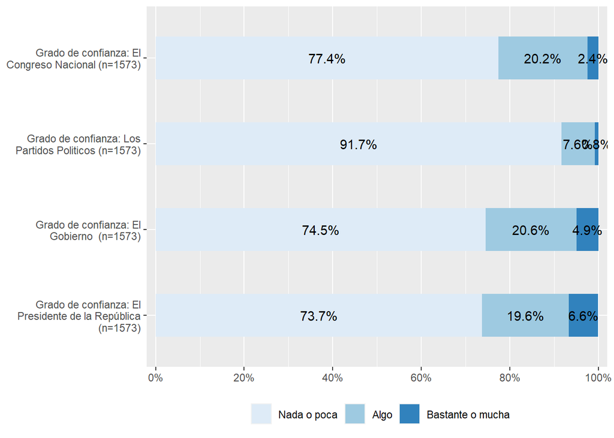

## 12.2 Descriptivos univariados de “Conocimiento político”

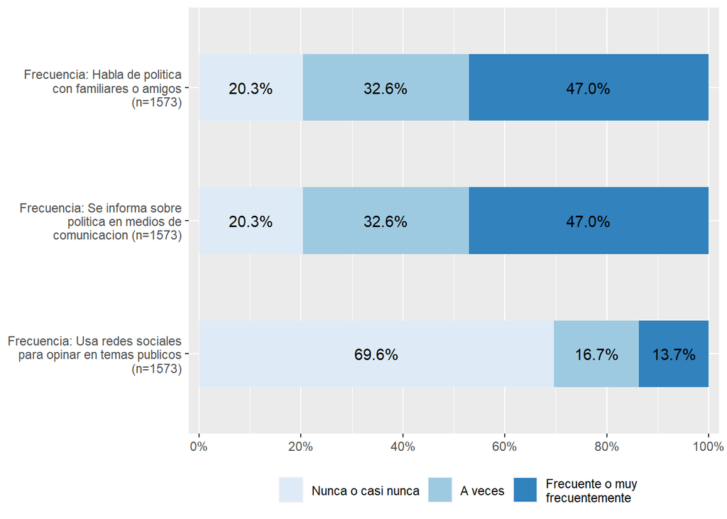

## 12.3 Descriptivos uniariados de “Percepciones hacia la democracia” 1

Distribución de las preferencias por régimen político

| Apoyo a la democracia | F. absoluta | F. relativa | F. rel. acumulada |
| --- | --- | --- | --- |
| La democracia es preferible a cualquier otra forma de gobierno | 862 | 54,8 % | 54,8 % |
| A la gente como uno, nos da lo mismo un regimen democratico que uno autoritario | 496 | 31,53 % | 86,33 % |
| En algunas circunstancias, un gobierno autoritario puede ser preferible a uno democratico | 215 | 13,67 % | 100 % |

Fuente:  
Elaboración propia en base a ELSOC (2021)

## 12.4 Descriptivos uniariados de “Percepciones hacia la democracia”

Distribución de la satisfacción con la democracia

| Satisfacción con la democracia | F. absoluta | F. relativa | F. rel. acumulada |
| --- | --- | --- | --- |
| Nada o poco satisfecho | 1062 | 67,51 % | 67,51 % |
| Algo satisfecho | 407 | 25,87 % | 93,39 % |
| Bastante o muy satisfecho | 104 | 6,61 % | 100 % |

Fuente:  
Elaboración propia en base a ELSOC (2021)

# 13. Gráficos bivariados

## 13.1 Gráficos bivariados: apoyo a la democracia según sexo

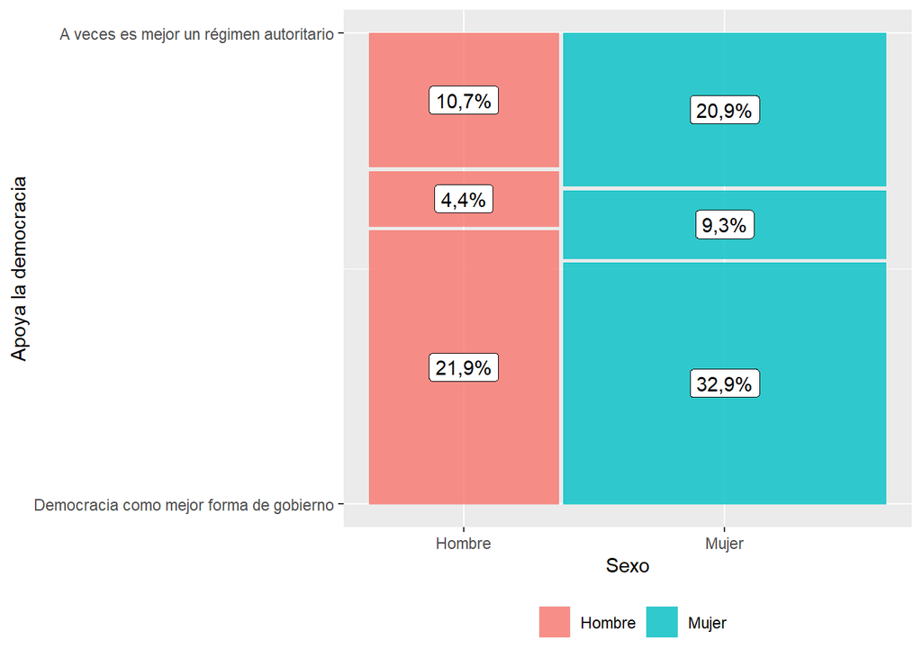

## 13.2 Gráficos bivariados: apoyo a la democracia según nivel educacional

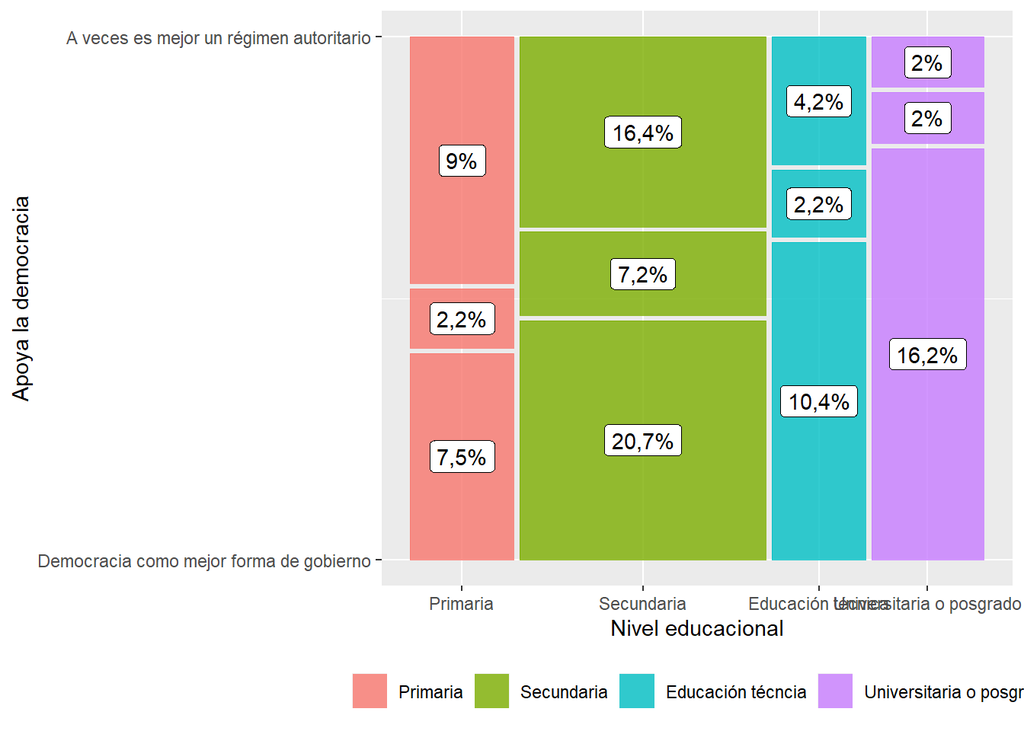

## 13.3 Gráficos bivariados: apoyo a la democracia según interés en la política

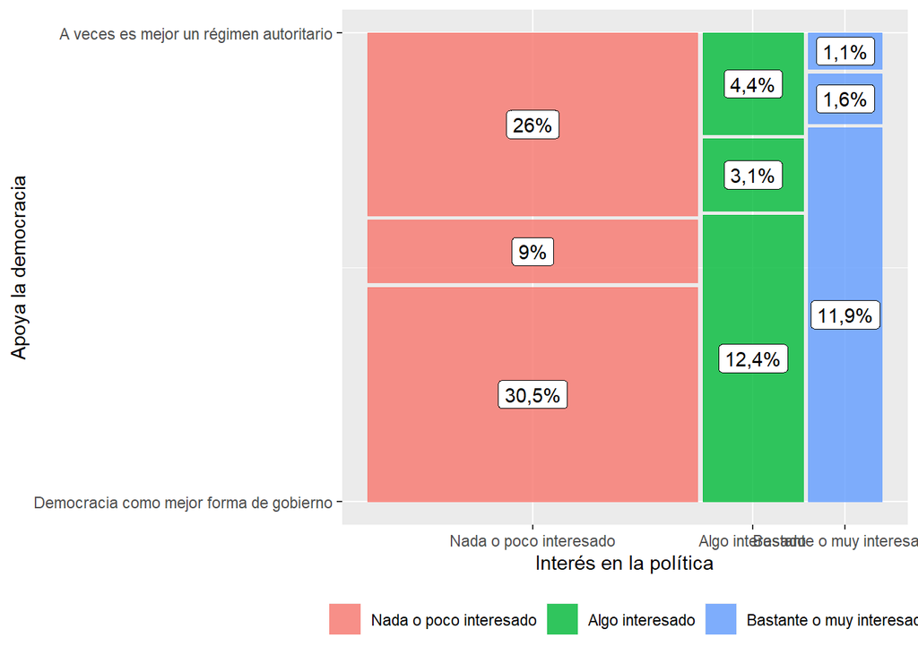

## 13.4 Gráficos bivariados: apoyo a la democracia según confianza en los partidos políticos

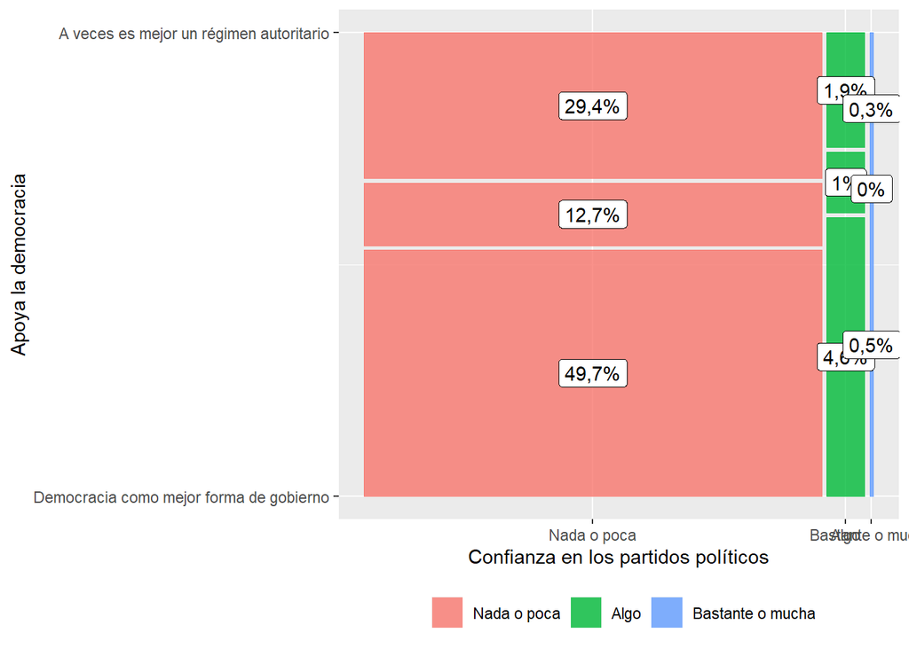

```
## Democracia o autoritarismo (x) <numeric>
## # total N=1573 valid N=1573 mean=0.55 sd=0.50
##
## Value |   N | Raw % | Valid % | Cum. %
## --------------------------------------
##     0 | 711 | 45.20 |   45.20 |  45.20
##     1 | 862 | 54.80 |   54.80 | 100.00
##  <NA> |   0 |  0.00 |    <NA> |   <NA>
```

```
##
##       Hombre Mujer  Sum
##   0      237   474  711
##   1      344   518  862
##   Sum    581   992 1573
```

## 13.5 Gráficos bivariados: apoyo a la democracia según la satisfacción con la democracia

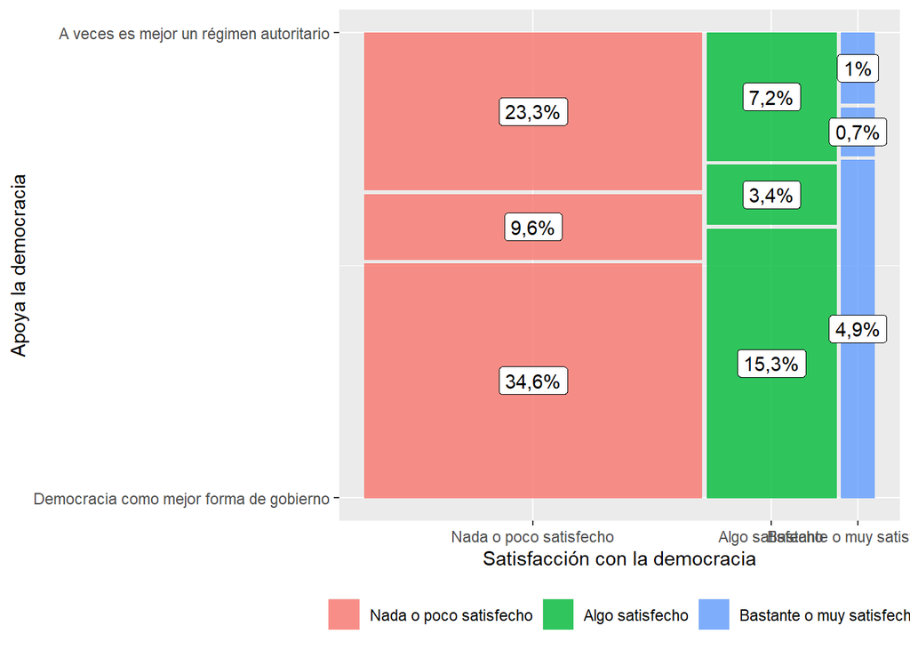

# 14. Modelos de regresión logística binaria

```
##   idencuesta estrato segmento ponderador02 confianza_gob confianza_pp
## 1          0       0        0            0             0            0
##   confianza_congreso confianza_pdte opina_rrss interes_politica
## 1                  0              0          0                0
##   informa_politica habla_politica ident_ideologica edad sexo nivel_educ
## 1                0              0                0    0    0          0
##   fact_exp02 satis_dem c25 apoyo_dem edad_tramo apoyo_dem_dic
## 1          0         0   0         0          0             0
```

## 14.1 Creación de objeto encuesta

## 14.2 Construcción múltiple de modelos logísticos

### Creamos modelos del 1:6 + un modelo 6 con diseño muestral complejo

```
##
## Call:
## svyglm(formula = apoyo_dem_dic ~ sexo + edad_tramo + nivel_educ +
##     interes_politica + confianza_pp + satis_dem, design = esi_design,
##     family = binomial(link = "logit"))
##
## Survey design:
## Called via srvyr
##
## Coefficients:
##                                           Estimate Std. Error t value Pr(>|t|)
## (Intercept)                                -0,1740     0,4108   -0,42  0,67186
## sexoMujer                                  -0,1162     0,1920   -0,61  0,54525
## edad_tramoAdulto                           -0,2566     0,3224   -0,80  0,42627
## edad_tramoAdulto mayor                     -0,0367     0,3816   -0,10  0,92346
## nivel_educSecundaria                        0,2554     0,2511    1,02  0,30938
## nivel_educEducación técnica                 0,6575     0,2965    2,22  0,02672
## nivel_educUniversitaria o posgrado          1,3205     0,3287    4,02  6,2e-05
## interes_politicaAlgo interesado             0,3011     0,2431    1,24  0,21560
## interes_politicaBastante o muy interesado   1,1852     0,3055    3,88  0,00011
## confianza_ppAlgo                           -0,2896     0,3979   -0,73  0,46678
## confianza_ppBastante o mucha                1,3892     0,7777    1,79  0,07424
## satis_demAlgo satisfecho                    0,3421     0,2603    1,31  0,18890
## satis_demBastante o muy satisfecho          0,4164     0,3722    1,12  0,26351
##
## (Intercept)
## sexoMujer
## edad_tramoAdulto
## edad_tramoAdulto mayor
## nivel_educSecundaria
## nivel_educEducación técnica               *
## nivel_educUniversitaria o posgrado        ***
## interes_politicaAlgo interesado
## interes_politicaBastante o muy interesado ***
## confianza_ppAlgo
## confianza_ppBastante o mucha              .
## satis_demAlgo satisfecho
## satis_demBastante o muy satisfecho
## ---
## Signif. codes:  0 '***' 0,001 '**' 0,01 '*' 0,05 '.' 0,1 ' ' 1
##
## (Dispersion parameter for binomial family taken to be 1)
##
## Number of Fisher Scoring iterations: 4
```

```
## [1] 1949
```

```
## [1] 1880
```

```
## $sexo
## # Predicted probabilities of Democracia o autoritarismo
##
## sexo | Predicted | group_col |       95% CI
## -------------------------------------------
##    1 |      0.46 |      sexo | [0.27, 0.65]
##    2 |      0.43 |      sexo | [0.26, 0.61]
##
## Adjusted for:
## *       edad_tramo =                  Joven
## *       nivel_educ =               Primaria
## * interes_politica = Nada o poco interesado
## *     confianza_pp =            Nada o poca
## *        satis_dem = Nada o poco satisfecho
##
## $edad_tramo
## # Predicted probabilities of Democracia o autoritarismo
##
## edad_tramo | Predicted |  group_col |       95% CI
## --------------------------------------------------
##          1 |      0.46 | edad_tramo | [0.27, 0.65]
##          2 |      0.39 | edad_tramo | [0.28, 0.52]
##          3 |      0.45 | edad_tramo | [0.31, 0.60]
##
## Adjusted for:
## *             sexo =                 Hombre
## *       nivel_educ =               Primaria
## * interes_politica = Nada o poco interesado
## *     confianza_pp =            Nada o poca
## *        satis_dem = Nada o poco satisfecho
##
## $nivel_educ
## # Predicted probabilities of Democracia o autoritarismo
##
## nivel_educ | Predicted |  group_col |       95% CI
## --------------------------------------------------
##          1 |      0.46 | nivel_educ | [0.27, 0.65]
##          2 |      0.52 | nivel_educ | [0.35, 0.69]
##          3 |      0.62 | nivel_educ | [0.44, 0.77]
##          4 |      0.76 | nivel_educ | [0.60, 0.87]
```

[output cut: 40 more lines]

```
## $satis_dem
## # Predicted probabilities of Democracia o autoritarismo
##
## satis_dem | Predicted | group_col |       95% CI
## ------------------------------------------------
##         1 |      0.46 | satis_dem | [0.27, 0.65]
##         2 |      0.54 | satis_dem | [0.33, 0.74]
##         3 |      0.56 | satis_dem | [0.32, 0.77]
##
## Adjusted for:
## *             sexo =                 Hombre
## *       edad_tramo =                  Joven
## *       nivel_educ =               Primaria
## * interes_politica = Nada o poco interesado
## *     confianza_pp =            Nada o poca
```

```
## $sexo
## # Predicted probabilities of Democracia o autoritarismo
##
## sexo | Predicted | group_col |       95% CI
## -------------------------------------------
##    1 |      0.39 |      sexo | [0.28, 0.52]
##    2 |      0.34 |      sexo | [0.24, 0.46]
##
## Adjusted for:
## *       edad_tramo =                  Joven
## *       nivel_educ =               Primaria
## * interes_politica = Nada o poco interesado
## *     confianza_pp =            Nada o poca
## *        satis_dem = Nada o poco satisfecho
##
## $edad_tramo
## # Predicted probabilities of Democracia o autoritarismo
##
## edad_tramo | Predicted |  group_col |       95% CI
## --------------------------------------------------
##          1 |      0.39 | edad_tramo | [0.28, 0.52]
##          2 |      0.36 | edad_tramo | [0.29, 0.43]
##          3 |      0.45 | edad_tramo | [0.37, 0.53]
##
## Adjusted for:
## *             sexo =                 Hombre
## *       nivel_educ =               Primaria
## * interes_politica = Nada o poco interesado
## *     confianza_pp =            Nada o poca
## *        satis_dem = Nada o poco satisfecho
##
## $nivel_educ
## # Predicted probabilities of Democracia o autoritarismo
##
## nivel_educ | Predicted |  group_col |       95% CI
## --------------------------------------------------
##          1 |      0.39 | nivel_educ | [0.28, 0.52]
##          2 |      0.46 | nivel_educ | [0.35, 0.58]
##          3 |      0.59 | nivel_educ | [0.47, 0.70]
##          4 |      0.74 | nivel_educ | [0.63, 0.82]
```

[output cut: 40 more lines]

```
## $satis_dem
## # Predicted probabilities of Democracia o autoritarismo
##
## satis_dem | Predicted | group_col |       95% CI
## ------------------------------------------------
##         1 |      0.39 | satis_dem | [0.28, 0.52]
##         2 |      0.45 | satis_dem | [0.32, 0.58]
##         3 |      0.54 | satis_dem | [0.37, 0.70]
##
## Adjusted for:
## *             sexo =                 Hombre
## *       edad_tramo =                  Joven
## *       nivel_educ =               Primaria
## * interes_politica = Nada o poco interesado
## *     confianza_pp =            Nada o poca
```

Modelo 0

Modelo 1

Modelo 2

Modelo 3

Modelo 4

Modelo 5

Modelo 6

Predictores

ß

ß

ß

ß

ß

ß

ß

(Intercept)

1.21 ***

1.45 ***

2.16 ***

0.67 ***

1.58 *

1.58 *

0.65

Sexo del entrevistada/o:  
Mujer

0.75 **

0.76 *

0.76 *

0.81

Edad por tramo: Adulto

0.52 ***

0.61 *

0.60 *

0.87

Edad por tramo: Adulto  
mayor

0.59 *

0.77

0.77

1.25

Nivel educacional:  
Secundaria

1.30

1.32

Nivel educacional:  
Educación técnica

2.41 ***

2.20 ***

Nivel educacional:  
Universitaria o posgrado

6.00 ***

4.27 ***

¿Qué tan interesado está  
usted en la política?:  
Algo interesado

1.89 ***

1.90 ***

1.51 **

¿Qué tan interesado está  
usted en la política?:  
Bastante o muy interesado

4.89 ***

4.89 ***

3.16 ***

Grado de confianza: Los  
Partidos Politicos: Algo

0.97

0.87

Grado de confianza: Los  
Partidos Politicos:  
Bastante o mucha

1.34

1.57

¿Cuán satisfecho o  
insatisfecho está usted  
con el funcionamiento de  
la democracia en Chile?:  
Algo satisfecho

1.23

¿Cuán satisfecho o  
insatisfecho está usted  
con el funcionamiento de  
la democracia en Chile?:  
Bastante o muy satisfecho

1.79 *

Observations

1573

1573

1573

1573

1573

1573

1573

R<sup>2</sup> Tjur

0.000

0.005

0.008

0.084

0.073

0.073

0.119

- p<0,05 ** p<0,01 *** p<0,001

```
## OK: Residuals appear to be independent and not autocorrelated (p = 0.468).
```

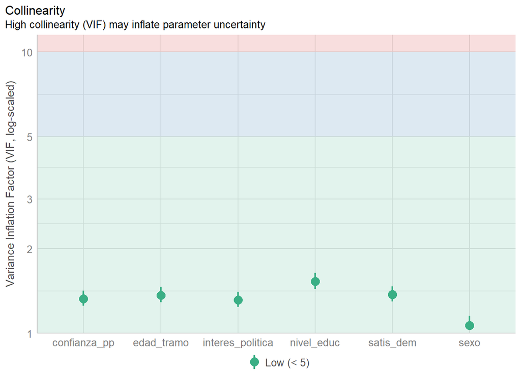

```
## # Check for Multicollinearity
##
## Low Correlation
##
##              Term  VIF   VIF 95% CI Increased SE Tolerance Tolerance 95% CI
##              sexo 1.06 [1.03, 1.15]         1.03      0.94     [0.87, 0.97]
##        edad_tramo 1.37 [1.29, 1.46]         1.17      0.73     [0.68, 0.78]
##        nivel_educ 1.53 [1.44, 1.64]         1.24      0.65     [0.61, 0.70]
##  interes_politica 1.31 [1.24, 1.40]         1.15      0.76     [0.71, 0.80]
##      confianza_pp 1.33 [1.25, 1.42]         1.15      0.75     [0.71, 0.80]
##         satis_dem 1.37 [1.30, 1.47]         1.17      0.73     [0.68, 0.77]
```

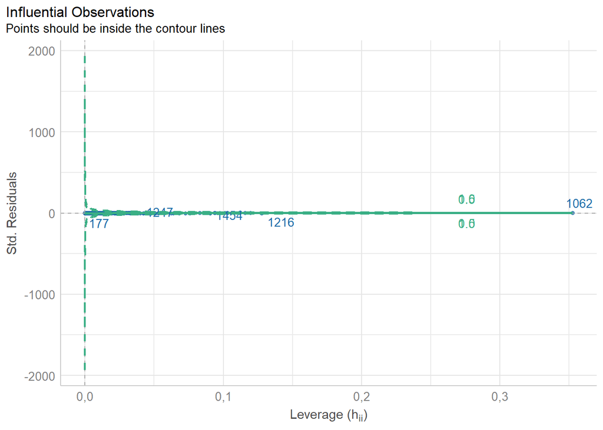

```
## OK: No outliers detected.
## - Based on the following method and threshold: cook (0,95).
## - For variable: (Whole model)
```

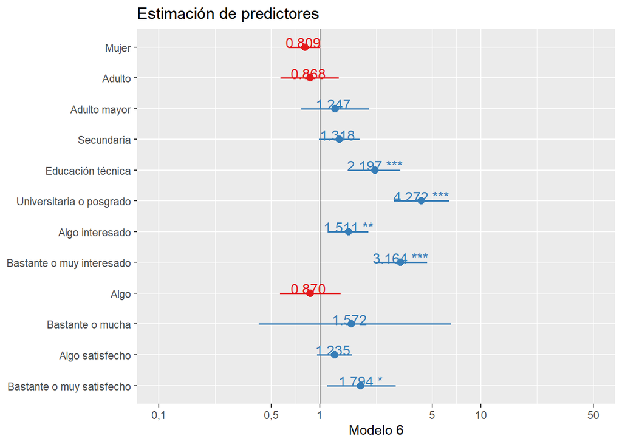

## 14.4 Representación de modelos en una tabla

Luego, se visualizan los todos los modelos (excepto modelo6survey) en una tabla única con coeficientes exponenciados correspondendientes a los Odds ratio que permiten reflejar la asociación entre las chances de las variables predictoras.